# Project proposal

Team number 4

## 1. Introduction

Public housing is government-owned housing units provided to low-income individuals and families who cannot afford market-rate housing. Currently, public housing companies which are mostly government-funded, own over 50,000 apartments across Israel. The Ministry of Construction only allows eligible individuals to obtain housing in their registered city, leading to around 4,300 people on the waiting list. Additionally, 25,000 more individuals, including 6,000 Holocaust survivors, face an average wait time of 3 to 4 years, with longer waits in Jerusalem and central regions. This situation prompts questions about the government’s public housing policy, which our project aims to address:  
**Is there a relation between general elections results per city, to the public housing procurement policy in the same city?**  
Our project aims to find a relation (if exist) between the elected government policy regarding public housing, to the top voted parties in each city.  
Does the government buy more apartments in cities who voted for her? Does it buy less apartments in cities which didn’t vote for her? In which cities does the government sell more housing units? In which regions there are more vacant apartments? Did those regions vote for the elected government? Since 2015, Israel has had 5 national elections, 4 different governments, and 7 different Construction Ministers. While previous research focused on apartment shortages and long waiting times, we aim to investigate if there’s a hidden government policy influenced by the vote rate in each city. We will combine public housing data (property purchases, vacant apartments, etc.) and election data (most elected parties per city) to find patterns indicating such policies.

## 3. Preliminary results

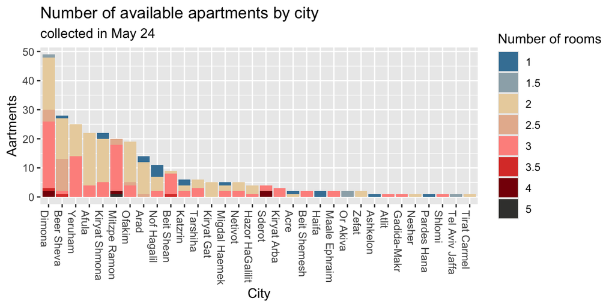

[figure not shown]

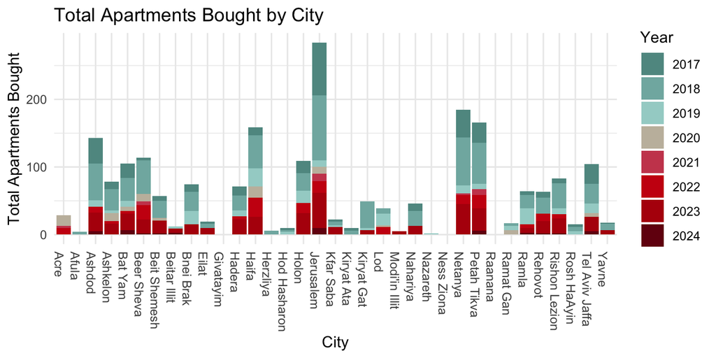

```
## # A tibble: 8 × 2
##    year total_apartments
##   <int>            <dbl>
## 1  2017              375
## 2  2018              781
## 3  2019              245
## 4  2020              131
## 5  2021               40
## 6  2022              196
## 7  2023              478
## 8  2024               58
```

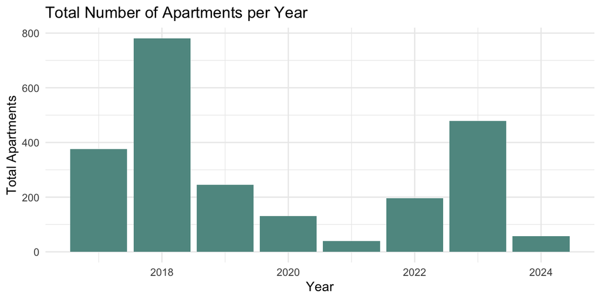

```
##      city_lms_name lamas_code year x3_rooms_apartments
## 1            Eilat       2600 2017                   2
## 2            Eilat       2600 2018                   1
## 3            Eilat       2600 2019                   7
## 4            Eilat       2600 2020                   1
## 5            Eilat       2600 2023                   2
## 6            Eilat       2600 2024                   1
## 7           Ashdod         70 2017                  16
## 8           Ashdod         70 2018                  33
## 9           Ashdod         70 2019                   6
## 10          Ashdod         70 2020                   5
## 11          Ashdod         70 2022                   3
## 12          Ashdod         70 2023                  10
## 13          Ashdod         70 2024                   2
## 14        Ashkelon       7100 2017                   4
```

[output cut: 612 more lines]

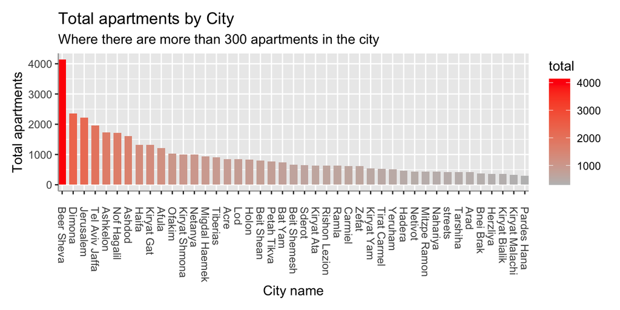

Looking at the data visualization and some summary statistics we can see that there are some concentrations for the current public housing system, where a major portion of the apartments are 2 and 3 rooms which may not help those who need them. Furthermore there is 1 company owning most of the apartments and a lot of the apartments are located in southern Israel in cities such as Be’er Sheva or Dimona.  
The elections results dataset is used mainly to determain the most voted party in a city, thus we didn’t include any explanatory statistics about it.

## 4. Data analysis plan

#### 1. Outcome (Response, Y) and Predictor (Explanatory, X) Variables

1. First Relation to examine : Outcome (Y): The number of houses bought per city per year. Explanatory (X): Segmentation of voting percentages in that city.
2. Second Relation to examine : Outcome (Y): The number of houses bought in a certain city in relation to the percentage of apartments available out of the total number of existing apartments in the city. Explanatory (X): Segmentation of voting percentages in that city.

#### 2. Comparison Groups

- Temporal Comparison: Different years where election results were different.
- Spatial Comparison: Different cities in the same year with varying voting patterns.

#### 3. Methods to Answer the Question

- **Data Preprocessing:** Ensuring all data is uniform, Predicting or imputing null values to complete the dataset. Removing duplicates, correcting errors, and ensuring consistency. Creating new variables or modifying existing ones to better fit the analysis
- **Descriptive Analysis:** Describe the current public housing procurement policy, its components, and influencing factors. make variable overview: Detail the apartment inventory, political state of the city, and other relevant variables.
- **Statistical Analysis:**
  - Logistic Regression: To model the probability of a certain number of houses being bought based on voting percentages.
  - Linear Regression: To measure the linear relationship between the number of houses bought and the voting percentages.
  - Comparative Analysis: Using t-tests or ANOVA to compare housing procurement policies across different cities and years based on their voting patterns.
  - Correlation Analysis: To check the strength and direction of the relationship between voting patterns and housing purchases.

#### 4. Necessary Results to Support the Hypothesis

1. Comparison Analysis: Identify and quantify differences in public housing procurement policies by comparing cities with different political leanings.
2. Inventory Analysis: Measure the percentage of vacant apartments and correlate this with housing purchases.

#### 5. Teamwork and Division of Work

- Dori: Data Collection and Preprocessing - Gather and clean data, handle translations, manage missing values.
- Daniel: Descriptive and Exploratory Analysis - Conduct descriptive analysis, visualize data, and provide initial insights.
- Ofek: Statistical Analysis - Perform logistic, linear, and non-linear regression analyses, comparative and correlation analyses.
- Shahaf: Reporting and Presentation - Consolidate findings, prepare the final report, and create visual presentations for clarity and communication of results.

To assure all team members experience every part of the data science, each task completed will be reviewed and confirmed by all team members before granting “Finished” status and merging to the project’s Master branch.  
In addition, we present a general division of work, which will change dynamically through the project’s progress according to the team’s demands and needs.

#### Collaboration and Communication:

Tedious work will happen offline where each person will work at home. We will share a **Git repository** to keep the R code updated. **Bi-weekly Zoom meetings** will be held to go over the tasks needed to be done, ensuring everyone is on track and any issues can be addressed promptly. This regular communication is essential, especially considering Daniel’s Miloim (reserve duty) commitments. During these meetings, we will review progress, plan next steps, and ensure alignment among all team members. By maintaining clear and consistent communication, we aim to work efficiently and effectively, despite being in different locations.

## Appendix

### Data README

```
SISE2601 Project data description
================ Team 4

Elect results: Rows: 12,545 Columns: 51

information about the last elections results in every ballot box in the country.

    ballot id – id of each ballot box. an integer number.
    Committee symbol – the ballot's geographical areas. Each area gets a number in range 1 to 20, ballot boxes inside IDF bases get 99.
    settlement name – the settlement of the ballot box.
    settlement ID – settlement's id of each ballot box.
    Ballot num – a float number that identifies the ballot box in its settlement. It can repeat itself in different settlements.
    BZB – number of eligible voters registered to the ballot box.
    Voters – number of votes in the ballot box.
    Rejected – number of uncounted votes in the ballot box.
    Accepted – number of counted votes in the ballot box.
    The rest of the variables are all the parties and how many votes each party got.

Properties by rooms: Rows: 843 Columns: 14

Each record represents a settlement, a floor number, and the number of public housing properties in the country which are from that settlement and on that floor number.

    CityLMSName – string of the settlement's name.
    Floor – floor number. Integer.
    OneRooms – number of one room apartments that exist in the settlement and on the floor number.
    TwoRooms – number of two rooms apartments that exists in the settlement and on the floor number. And it continues this way until TenRooms, and MoreRooms (more than 10) variables.

Property purchases: Rows: 208 Columns: 7

Information about public housing property purchasing per settlement & year.

    Lamas code – identification number of a settlement.
    Year – 2017 – 2024.
    Lamas name – the settlement's name.
    3 rooms apartments – number of purchased 3 rooms apartments.
    4+ rooms apartments – number of purchased 4 or more rooms apartments.
    average price (NIS) 3 rooms apartments – the average purchase price of 3 rooms apartment.
    average price (NIS) 4+ rooms apartments – the average purchase price of 4 or more rooms apartment.

Vacant apartments: Rows: 277 Columns: 14

List of public housing apartments that have been available for more than 3 months.

    CityLmsName – settlement's name.
    CityLmsCode – settlement id, number.
    NumOfRooms – number of rooms in the apartment (a float number because there're apartments with half-rooms).
    Floor – apartment's floor number.
    TotalArea – area of the apartment in square meter.
    CompanyName – the company that owns the apartment.
    StatusChangeDate – date the apartment has been available from.
```